# Lorem ipsum dolor sit amet

#### Comparison among Political Tendencies

Next I’m interested in how the *political tendencies* affect voters. Using the same way to evaluate importance, I used a heatmap to illustrate this topic. From the questionnaire I summed up some political factors that are mentioned and evaluated in the questionnaire. Though I’m not an expertise in social sciencs, we could still see something from the results.

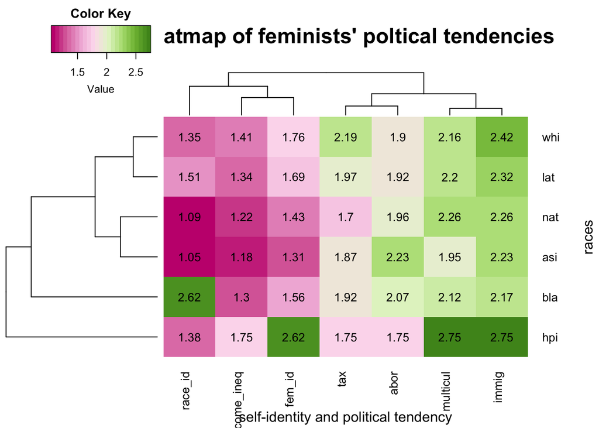

The value of black people’s race identity stands out, demonstrating saliently that

> Black people have the highest race identity importance index.

This map also gives us insights on the priority of policies of feminists. Kind of counterintuitively, the priority orders of politics issues are:

> Immigration > Multiculturism > Aborthion > Tax > Feminists’ Identity > Income Inequality > Races’ Identity

Even for feminists, feminism is not the biggest issue in considering a new president.

The next is a radar plot comparing the same thing but with a better visualization display.

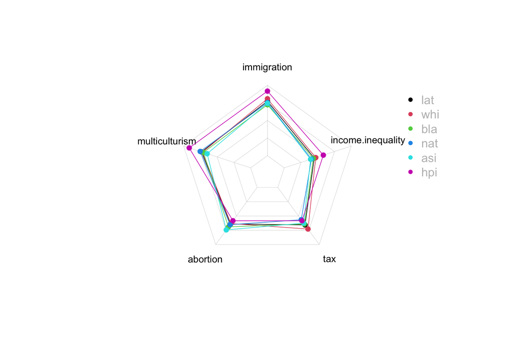

Is it because of their culture background OR is there something wrong with the data analysis process?

```r
nrow(femHpi)
```

```
## [1] 4
```

#### Conclusions

Immigration > Multiculturalism > Aborthion > Tax > Feminists’ Identity > Income Inequality > Races’ Identity

- Black people have the highest race identity importance index.
- Black or African American feminists tend to value ethnicity more than feminism.

#### Thoughts on the Questionnaire and My Research

- The questionnaire give much space on multiculturalism and racism. While there are many questions about that, it gives people the feeling that it is more important and deserve better focus. However, there are only 2 questions about feminism, leaving it rather neglectable and thus may cause bias.
- The sample size I’m dealing with is rather small. Since I’m interested in feminism, I did my analysis on feminists of the voters. Like the HPI feminists only has a sample size of 4. Although that’s what I’m interested in ,it’s still true that I did not fully utilize the data.

**Thanks for watching**